# SIV Risk Factor Analysis: BinaryPLSR (PLS-DA)

### 3. Risk and Protective Factors

#### Component 1 Risk/Protective Factors

|  | Predictor | Loading | Type |
| --- | --- | --- | --- |
| 1 | contact_bird_in_stable_TRUE | -0.2526246251814737 | Risk Factor |
| 2 | ai_airspace_with_other_agegroup_2 | -0.2337932872508219 | Risk Factor |
| 3 | litter_equalization_farrowing_stable_2 | 0.2299062434114914 | Protective Factor |
| 4 | drying_farrowing_stable_TRUE | 0.1976197089556256 | Protective Factor |
| 5 | ai_airspace_with_other_agegroup_3 | 0.1867397016675385 | Protective Factor |
| 6 | caretaker_entry_ppe_only_TRUE | -0.1864096032504132 | Risk Factor |
| 7 | production_cycle_1 | -0.184335084412726 | Risk Factor |
| 8 | outside_area_contact_wild_boars_TRUE | 0.1737237320999064 | Protective Factor |
| 9 | mode_stable_occupation_gilts_stable_TRUE | 0.1676251661466337 | Protective Factor |
| 10 | seperation_quarantaine_area_2 | -0.1559685163000982 | Risk Factor |

[output cut: 106 more lines]

#### Component 2 Risk/Protective Factors

|  | Predictor | Loading | Type |
| --- | --- | --- | --- |
| 1 | mode_stable_occupation_ai_centre_NA | 0.2490276157883738 | Protective Factor |
| 2 | mode_stable_occupation_fattener_stable_TRUE | 0.2347263487781102 | Protective Factor |
| 3 | outside_area_contact_wild_birds_TRUE | -0.1863935877107318 | Risk Factor |
| 4 | desinfection_weaner_stable_1 | -0.1847513143471528 | Risk Factor |
| 5 | farrowing_airspace_with_other_agegroup_NA | 0.1829464491987124 | Protective Factor |
| 6 | gilts_airspace_with_other_agegroup_3 | -0.1787213487956244 | Risk Factor |
| 7 | Weaners_on_farm_TRUE | -0.1760890006330507 | Risk Factor |
| 8 | mode_stable_occupation_ai_centre_TRUE | -0.1745146368639782 | Risk Factor |
| 9 | ai_airspace_with_other_agegroup_2 | -0.1724912570501175 | Risk Factor |
| 10 | mode_stable_occupation_farrowing_stable_TRUE | -0.1636063724601966 | Risk Factor |

[output cut: 106 more lines]

#### Variable Importance in Projection (VIP) Scores

|  | Predictor | VIP Score |
| --- | --- | --- |
| 1 | ai_airspace_with_other_agegroup_2 | 2.061273723869535 |
| 2 | contact_bird_in_stable_TRUE | 1.985535200991444 |
| 3 | litter_equalization_farrowing_stable_2 | 1.765969458419802 |
| 4 | mode_stable_occupation_fattener_stable_TRUE | 1.631645261741522 |
| 5 | drying_farrowing_stable_TRUE | 1.622546986857972 |
| 6 | mode_stable_occupation_gilts_stable_TRUE | 1.551186095451115 |
| 7 | mode_stable_occupation_ai_centre_NA | 1.534126272100312 |
| 8 | farrowing_airspace_with_other_agegroup_3 | 1.505429878398612 |
| 9 | Isemination_on_farm_TRUE | 1.465161685860614 |
| 10 | ai_airspace_with_other_agegroup_3 | 1.439646637457165 |

[output cut: 106 more lines]

### 4. Model Performance Summary

#### Confusion Matrix

Confusion Matrix

|  | FALSE | TRUE |
| --- | --- | --- |
| FALSE | 62 | 12 |
| TRUE | 12 | 39 |

#### Performance Metrics

Performance Metrics

| Metric | Value |
| --- | --- |
| Sensitivity | 0.765 |
| Specificity | 0.838 |
| Balanced Accuracy | 0.801 |
| AUC | 0.895 |

#### ROC Curve

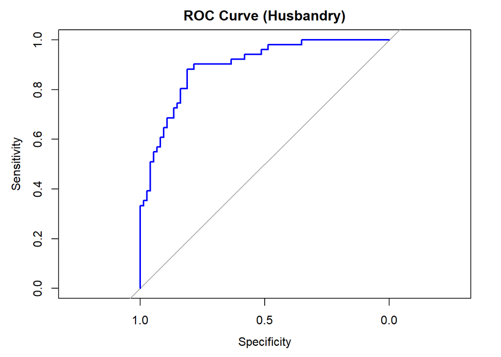

## Animal Health Predictors

### Analysis Summary

- **Subset:** Animal Health
- **Sample Size:** 125
- **Predictors after filtering:** 56
- **Optimal number of components:** 1
- **Variance explained by each component:** 13.34, 9.94, 3.66 %
- **SIV Status Class Balance:**
  - Negative: 74 (59.2%)
  - Positive: 51 (40.8%)

### 1. PLS-DA Sample Scores Plot

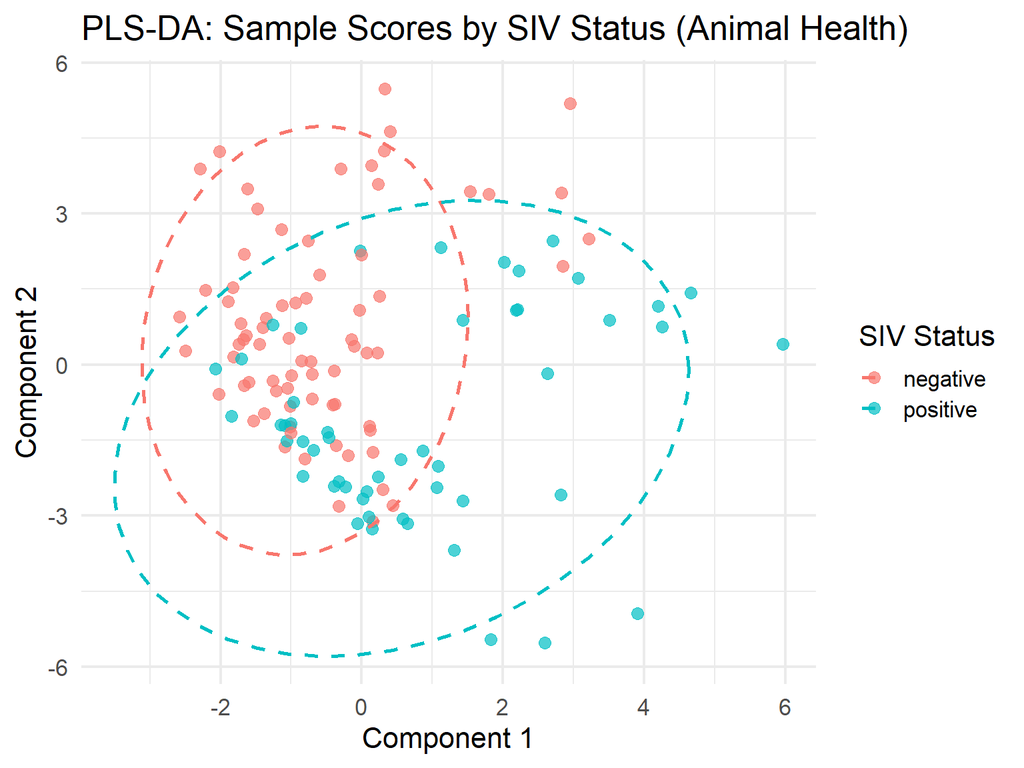

### 2. RMSEP Plot (Model Validation)

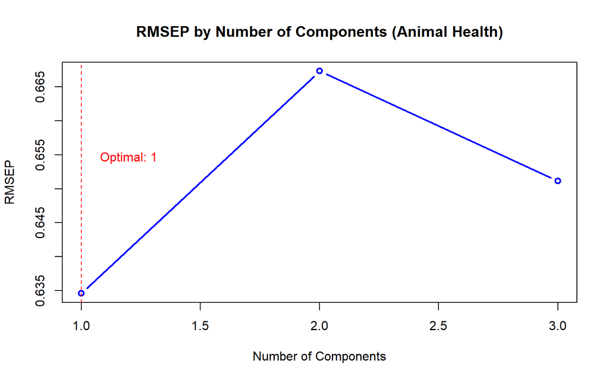

### 3. Risk and Protective Factors

#### Component 1 Risk/Protective Factors

|  | Predictor | Loading | Type |
| --- | --- | --- | --- |
| 1 | respiratory_history_swine_3 | 0.392898131926609 | Risk Factor |
| 2 | farrowing_piglet_litters_sneezing_TRUE | -0.3192256530782072 | Protective Factor |
| 3 | symptom_swine_nasal_discharge_TRUE | 0.2733505494717392 | Risk Factor |
| 4 | weaners_diseased_TRUE | 0.2264249127460399 | Risk Factor |
| 5 | symptom_swine_dyspnoea_TRUE | -0.2154602725348961 | Protective Factor |
| 6 | symptomatic_report_TRUE | 0.214477761581347 | Risk Factor |
| 7 | ili_signs_TRUE | 0.1781053791751301 | Risk Factor |
| 8 | weaners_coughing_5+ | -0.1730944292002558 | Protective Factor |
| 9 | Isemination_on_farm_TRUE | -0.165903498015349 | Protective Factor |
| 10 | symptom_swine_fever_TRUE | 0.1637090073008603 | Risk Factor |

[output cut: 46 more lines]

#### Component 2 Risk/Protective Factors

|  | Predictor | Loading | Type |
| --- | --- | --- | --- |
| 1 | piglets_per_sow_year_TRUE | -0.2800671076045806 | Risk Factor |
| 2 | farrowing_rate_TRUE | -0.2529258131520308 | Risk Factor |
| 3 | fatteners_diseased_TRUE | 0.2311670488904269 | Protective Factor |
| 4 | weaners_sneezing_NA | 0.2266104771447619 | Protective Factor |
| 5 | abortions_per_sow_year_TRUE | -0.2261635955460621 | Risk Factor |
| 6 | fatteners_sneezing_NA | -0.2251079452270144 | Risk Factor |
| 7 | piglet_mortality_TRUE | -0.2054232340421446 | Risk Factor |
| 8 | return_to_service_rate_TRUE | -0.2042636308366973 | Risk Factor |
| 9 | weaners_reduced_general_wellbeing_NA | 0.2015046029768189 | Protective Factor |
| 10 | symptom_swine_dyspnoea_TRUE | 0.1966609607696253 | Protective Factor |

[output cut: 46 more lines]

#### Variable Importance in Projection (VIP) Scores

|  | Predictor | VIP Score |
| --- | --- | --- |
| 1 | respiratory_history_swine_3 | 2.940180395145758 |
| 2 | farrowing_piglet_litters_sneezing_TRUE | 2.388866045775619 |
| 3 | symptom_swine_nasal_discharge_TRUE | 2.045568205219297 |
| 4 | weaners_diseased_TRUE | 1.694408894651731 |
| 5 | symptom_swine_dyspnoea_TRUE | 1.612357040573041 |
| 6 | symptomatic_report_TRUE | 1.605004601839174 |
| 7 | ili_signs_TRUE | 1.332818615229599 |
| 8 | weaners_coughing_5+ | 1.295320099253112 |
| 9 | Isemination_on_farm_TRUE | 1.241508097681533 |
| 10 | rectal_temperature_avg_&lt;40.0 | 1.225086032897386 |

[output cut: 46 more lines]

### 4. Model Performance Summary

#### Confusion Matrix

Confusion Matrix

|  | FALSE | TRUE |
| --- | --- | --- |
| FALSE | 68 | 6 |
| TRUE | 28 | 23 |

#### Performance Metrics

Performance Metrics

| Metric | Value |
| --- | --- |
| Sensitivity | 0.451 |
| Specificity | 0.919 |
| Balanced Accuracy | 0.685 |
| AUC | 0.738 |

#### ROC Curve

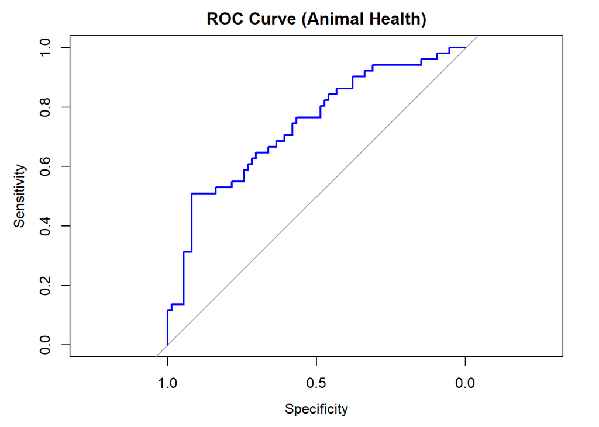

## Environment Predictors

### Analysis Summary

- **Subset:** Environment
- **Sample Size:** 125
- **Predictors after filtering:** 85
- **Optimal number of components:** 1
- **Variance explained by each component:** 10.51, 6.81, 3.6 %
- **SIV Status Class Balance:**
  - Negative: 74 (59.2%)
  - Positive: 51 (40.8%)

### 1. PLS-DA Sample Scores Plot

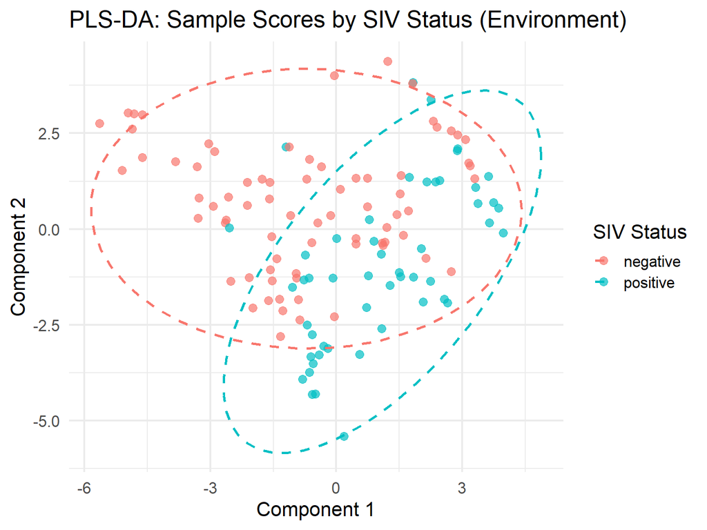

### 2. RMSEP Plot (Model Validation)

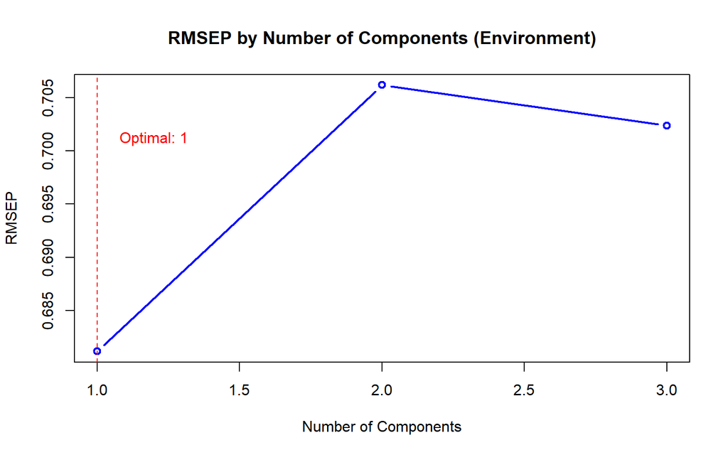

### 3. Risk and Protective Factors

#### Component 1 Risk/Protective Factors

|  | Predictor | Loading | Type |
| --- | --- | --- | --- |
| 1 | season_sampling_summer | -0.2357048156366816 | Protective Factor |
| 2 | ai_sows_airflow_0.1–&lt;0.2 | -0.2297041816957145 | Protective Factor |
| 3 | ai_sows_room_temperature_&gt;=24 | -0.2250514611698944 | Protective Factor |
| 4 | gilts_room_temperature_&gt;=25 | -0.2250514611698942 | Protective Factor |
| 5 | gilts_airflow_&gt;=0.4 | -0.2230701018422383 | Protective Factor |
| 6 | season_sampling_autumn | 0.2174126905399753 | Risk Factor |
| 7 | gilts_airflow_NA | 0.1919090760386456 | Risk Factor |
| 8 | weaners_animals_per_feeding_site_factor_trough | -0.1872836487962556 | Protective Factor |
| 9 | weaners_airflow_&gt;=0.4 | -0.178107566672322 | Protective Factor |
| 10 | weaners_room_temperature_NA | 0.1770877563063726 | Risk Factor |

[output cut: 75 more lines]

#### Component 2 Risk/Protective Factors

|  | Predictor | Loading | Type |
| --- | --- | --- | --- |
| 1 | farrowing_airflow_NA | 0.2419541236142764 | Protective Factor |
| 2 | farrowing_room_temperature_NA | 0.2185014360482612 | Protective Factor |
| 3 | gilts_qm_per_animal_NA | 0.2043456682620769 | Protective Factor |
| 4 | farrowing_nest_temperature_ok_NA | 0.2001774722748584 | Protective Factor |
| 5 | farrowing_nest_temperature_ok_TRUE | -0.2000801877334561 | Risk Factor |
| 6 | gilts_room_temperature_17–&lt;21 | -0.197848764435664 | Risk Factor |
| 7 | ai_sows_airflow_NA | 0.1968419692151704 | Protective Factor |
| 8 | ai_sows_airflow_0.2–&lt;0.4 | -0.1959782877820802 | Risk Factor |
| 9 | farrowing_room_temperature_&lt;17 | -0.1795900507627116 | Risk Factor |
| 10 | gilts_airflow_NA | 0.1771471102549785 | Protective Factor |

[output cut: 75 more lines]

#### Variable Importance in Projection (VIP) Scores

|  | Predictor | VIP Score |
| --- | --- | --- |
| 1 | season_sampling_summer | 2.17309102656041 |
| 2 | ai_sows_airflow_0.1–&lt;0.2 | 2.117767915169723 |
| 3 | ai_sows_room_temperature_&gt;=24 | 2.074871951434565 |
| 4 | gilts_room_temperature_&gt;=25 | 2.074871951434563 |
| 5 | gilts_airflow_&gt;=0.4 | 2.056604721027369 |
| 6 | season_sampling_autumn | 2.004445966012963 |
| 7 | gilts_airflow_NA | 1.769314258296294 |
| 8 | weaners_animals_per_feeding_site_factor_trough | 1.726669926201106 |
| 9 | weaners_airflow_&gt;=0.4 | 1.64207062911573 |
| 10 | weaners_room_temperature_NA | 1.632668442108851 |

[output cut: 75 more lines]

### 4. Model Performance Summary

#### Confusion Matrix

Confusion Matrix

|  | FALSE | TRUE |
| --- | --- | --- |
| FALSE | 53 | 21 |
| TRUE | 25 | 26 |

#### Performance Metrics

Performance Metrics

| Metric | Value |
| --- | --- |
| Sensitivity | 0.510 |
| Specificity | 0.716 |
| Balanced Accuracy | 0.613 |
| AUC | 0.738 |

#### ROC Curve

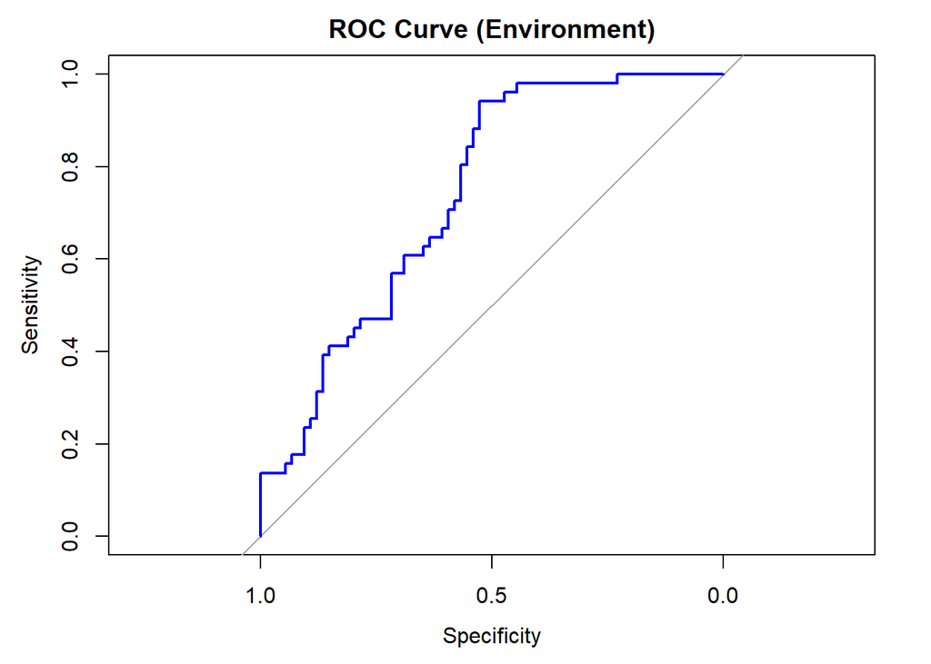

## Human/Contact Predictors

### Analysis Summary

- **Subset:** Human/Contact
- **Sample Size:** 125
- **Predictors after filtering:** 15
- **Optimal number of components:** 1
- **Variance explained by each component:** 25.33, 13.73, 6.04 %
- **SIV Status Class Balance:**
  - Negative: 74 (59.2%)
  - Positive: 51 (40.8%)

### 1. PLS-DA Sample Scores Plot

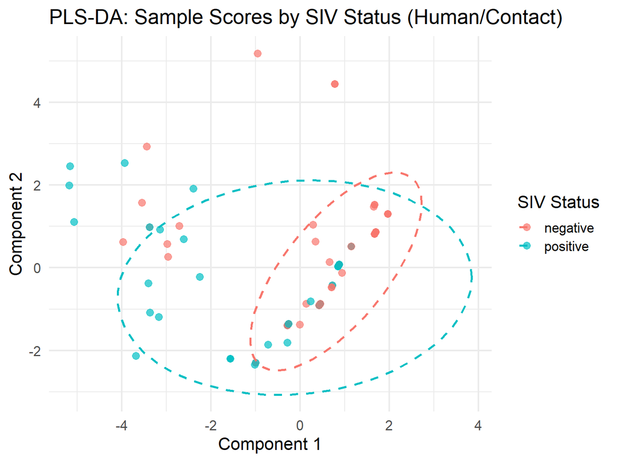

### 2. RMSEP Plot (Model Validation)

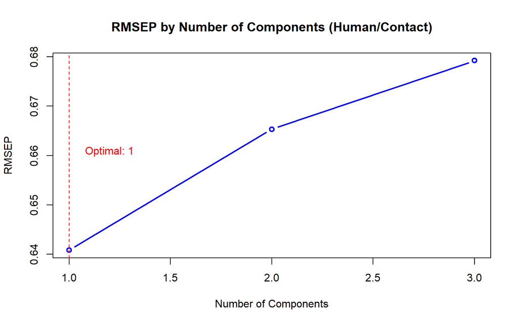